# PA1_stacy.RMD

C Stacy

November 15, 2015

## Loading and Preprocessing the data

```r
library(data.table)
activity <- read.csv(file="~/Downloads/activity.csv", header=TRUE)
activity.dt <- data.table(activity)
obs <- dim(activity.dt)[1]
```

## What is mean total number of steps taken per day?

1. Make a histogram of the total number of steps taken each day

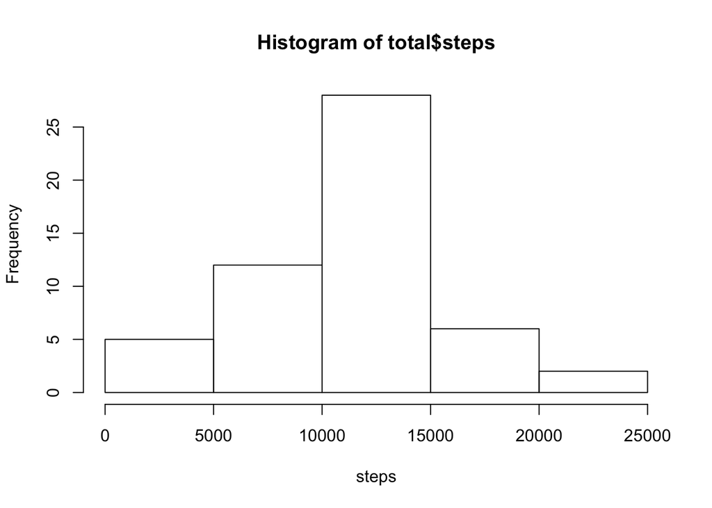

```r
# determine the total number of steps taken for each date
total <- activity.dt[,lapply(.SD,sum),by="date",.SDcols=1]
# plot the histogram of the total steps per day
hist(total$steps, xlab="steps")
```

2. Calculate and report the mean and median total number of steps taken per day

```r
# determine the mean steps for each date
mean_day <- activity.dt[,lapply(.SD, mean),by="date",.SDcols=1]
mean_day
```

```
##           date      steps
##  1: 2012-10-01         NA
##  2: 2012-10-02  0.4375000
##  3: 2012-10-03 39.4166667
##  4: 2012-10-04 42.0694444
##  5: 2012-10-05 46.1597222
##  6: 2012-10-06 53.5416667
##  7: 2012-10-07 38.2465278
##  8: 2012-10-08         NA
##  9: 2012-10-09 44.4826389
## 10: 2012-10-10 34.3750000
## 11: 2012-10-11 35.7777778
## 12: 2012-10-12 60.3541667
## 13: 2012-10-13 43.1458333
## 14: 2012-10-14 52.4236111
```

[output cut: 48 more lines]

```r
# determine the median steps for each date
activity.dt[,lapply(.SD, function(x) as.numeric(median(x))),by="date",.SDcols=1]
```

```
##           date steps
##  1: 2012-10-01    NA
##  2: 2012-10-02     0
##  3: 2012-10-03     0
##  4: 2012-10-04     0
##  5: 2012-10-05     0
##  6: 2012-10-06     0
##  7: 2012-10-07     0
##  8: 2012-10-08    NA
##  9: 2012-10-09     0
## 10: 2012-10-10     0
## 11: 2012-10-11     0
## 12: 2012-10-12     0
## 13: 2012-10-13     0
## 14: 2012-10-14     0
```

[output cut: 48 more lines]

### What is the average daily activity pattern?

1. Make a time series plot (i.e. type = “l”) of the 5-minute interval (x-axis) and the average number of steps taken, averaged across all days (y-axis)

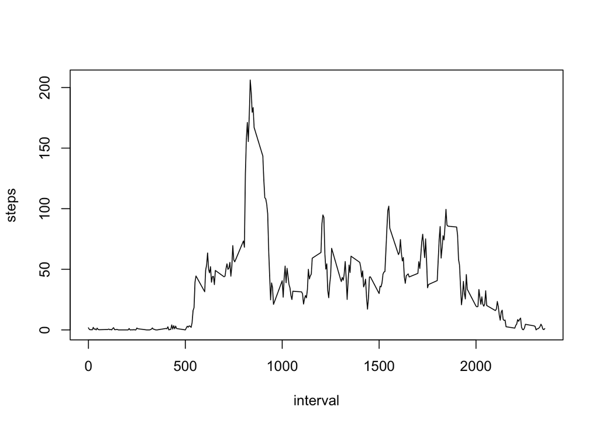

```r
# determine the average number of steps taken across all the days per the 5-min intervals
daily <- activity.dt[,lapply(.SD, mean, na.rm=TRUE),by="interval",.SDcols=1]
# plot the result in a line graph
plot(daily,type="l")
```

2. Which 5-minute interval, on average across all the days in the dataset, contains the maximum number of steps?

```r
# determine the value of max steps
max_steps <- max(daily$steps)
# determine the interval value of the max steps
i <- 1
result <- 0
while(daily$steps[i] < max_steps){
        i <- i+1
        result <- daily$interval[i]
}
max_steps
```

```
## [1] 206.1698
```

```r
result
```

```
## [1] 835
```

## Inputing missing values

1. Calculate and report the total number of missing values in the dataset (i.e. the total number of rows with NAs)

```r
colSums(is.na(activity.dt))
```

```
##    steps     date interval
##     2304        0        0
```

2. Devise a strategy for filling in all of the missing values in the dataset. The strategy does not need to be sophisticated. For example, you could use the mean/median for that day, or the mean for that 5-minute interval, etc.

```r
# replace the NA values with 0 for the mean steps per day matrix
mean_day[is.na(mean_day)] <- 0
```

3. Create a new dataset that is equal to the original dataset but with the missing data filled in.

```r
newSet.dt <- data.table(activity)
i <- 1
j <- 1
while(i <= obs) {
        if(is.na(newSet.dt$steps[i])){
                newSet.dt$steps[i] <- mean_day$steps[j]
        }
        if(i/288==1){
                j <- j+1
        }
        i <- i+1
}
```

4. Make a histogram of the total number of steps taken each day and Calculate and report the mean and median total number of steps taken per day. Do these values differ from the estimates from the first part of the assignment? What is the impact of imputing missing data on the estimates of the total daily number of steps?

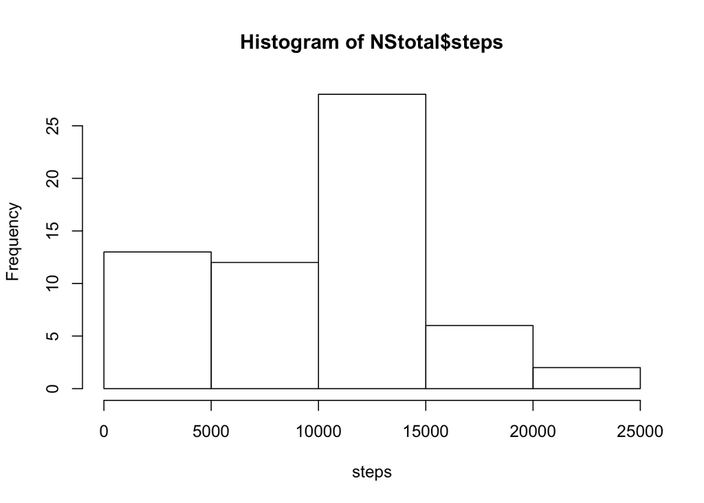

```r
# determine the total number of steps taken for each date
NStotal <- newSet.dt[,lapply(.SD,sum),by="date",.SDcols=1]
# plot the histogram of the total steps per day
hist(NStotal$steps, xlab="steps")
```

```r
# determine the mean steps for each date
newSet.dt[,lapply(.SD, mean),by="date",.SDcols=1]
```

```
##           date      steps
##  1: 2012-10-01  0.0000000
##  2: 2012-10-02  0.4375000
##  3: 2012-10-03 39.4166667
##  4: 2012-10-04 42.0694444
##  5: 2012-10-05 46.1597222
##  6: 2012-10-06 53.5416667
##  7: 2012-10-07 38.2465278
##  8: 2012-10-08  0.4375000
##  9: 2012-10-09 44.4826389
## 10: 2012-10-10 34.3750000
## 11: 2012-10-11 35.7777778
## 12: 2012-10-12 60.3541667
## 13: 2012-10-13 43.1458333
## 14: 2012-10-14 52.4236111
```

[output cut: 48 more lines]

```r
# determine the median steps for each date
newSet.dt[,lapply(.SD, function(x) as.numeric(median(x))),by="date",.SDcols=1]
```

```
##           date  steps
##  1: 2012-10-01 0.0000
##  2: 2012-10-02 0.0000
##  3: 2012-10-03 0.0000
##  4: 2012-10-04 0.0000
##  5: 2012-10-05 0.0000
##  6: 2012-10-06 0.0000
##  7: 2012-10-07 0.0000
##  8: 2012-10-08 0.4375
##  9: 2012-10-09 0.0000
## 10: 2012-10-10 0.0000
## 11: 2012-10-11 0.0000
## 12: 2012-10-12 0.0000
## 13: 2012-10-13 0.0000
## 14: 2012-10-14 0.0000
```

[output cut: 48 more lines]

1. Create a new factor variable in the dataset with two levels – “weekday” and “weekend” indicating whether a given date is a weekday or weekend day.

```r
# create a new column
newcolname = "week"
    newSet.dt[,newcolname:=NA,with=FALSE]

# determine day of the week
activity$date <- as.POSIXlt(activity$date,format="%Y-%m-%d")
allDays <- weekdays(activity$date)

# based on day of the week set the new column values
i <- 1
while(i <= obs) {
        if(allDays[i]==("Sunday")) {
                newSet.dt$week[i] <- "end"
        }
        if(allDays[i]==("Saturday")) {
                newSet.dt$week[i] <- "end"
        }
        else(newSet.dt$week[i]<- "day")
        i <- i+1
}
```

```r
# determine the average number of steps taken across all the weekdays per the 5-min intervals
#NSend <- data.frame(steps=integer(),
#                    date=as.Date(character()),
#                    interval=integer(),
#                    week=character(),
#                    stringsAsFactors=FALSE)
#NSday <- data.frame(steps=integer(),
#                    date=as.Date(character()),
#                    interval=integer(),
#                    week=character(),
#                    stringsAsFactors=FALSE)
#i <- 1
#j <- 1
#k <- 1

#while(i <= obs){
#        if(newSet.dt$week[i] == "end"){
#                NSend[j] <- newSet.dt[i]
#                j <- j+1
#        }
#        else{
#                NSday[k] <- newSet.dt[i]
#               k <- k+1
#        }
#        i <- i+1
#}

#weekday<-NSday[,lapply(.SD, mean), by="interval",.SDcols=1]
#weekend<-NSend[,lapply(.SD, mean), by="interval",.SDcols=1]

# plot the result in a line graph
#attach(mtcars)
#par(mfrow=c(2,1))
#plot(weekday,type="l", main="Weekdays")
#plot(weekend,type="l", main="Weekends")
```

I had a difficult time with the coding. I think I need to review R more before trying the next assignment. :(